# Bayesian T-Tests Study 3 to 7

S. Casey O’Donnell

10/17/2021

run the models using BayesFactor package and the ttestBF command.

For each study, I run four commands. One pair refers to the sample #when inaccurate responses are included (e.g., m1 and m1_post) vs. the other pair (e.g., m1_accur and m1_accur post that only examines respondents with Difficulty Association Task accuracies greater or equal to 75%. The “post” subscript indicates that I’m running a command that samples from the posterior distribution so that I can describe the parameter of interest: sample mean dscore. The difference between posterior and observed is the prior. In the null model (not depicted but described in the syntax for the command: ?ttestBF), the prior on mu (or mean dscore) is defined as a spike on 0 (a dscore indicating neither a tendency to associate difficulty with impossibility or importance). In the alternative model, the prior is non-informative cauchy prior which, in lay terms, basically says the mean could plausibly fall anywhere in a particular range centered on zero and could be stated as the naive hypothesis that a difference from zero is possible.

```r
#set seed to yield consistent results on re-running syntax
set.seed(31234)
m1<- ttestBF(study3$dscore, mu=0, posterior = FALSE, data=study3 ,
             iterations=2000)
m1_post<- ttestBF(study3$dscore, mu=0, posterior = TRUE, data=study3 ,
             iterations=2000)
m1_acc<- ttestBF(study3Accurate$dscore, mu=0, posterior = FALSE, data=study3 ,
             iterations=2000)
m1_post_acc<- ttestBF(study3Accurate$dscore, mu=0, posterior = TRUE, data=study3 ,
             iterations=2000)
m2<- ttestBF(study4$dscore, mu=0, posterior = FALSE, data=study4 ,
             iterations=2000)
m2_post<- ttestBF(study4$dscore, mu=0, posterior = TRUE, data=study4 ,
             iterations=2000)
m2_acc<- ttestBF(study4Accurate$dscore, mu=0, posterior = FALSE, data=study4 ,
             iterations=2000)
m2_post_acc<- ttestBF(study4Accurate$dscore, mu=0, posterior = TRUE, data=study4 ,
             iterations=2000)
m3<- ttestBF(study5$dscore, mu=0, posterior = FALSE, data=study5 ,
             iterations=2000)
m3_post<- ttestBF(study5$dscore, mu=0, posterior = TRUE, data=study5 ,
             iterations=2000)
m3_acc<- ttestBF(study5Accurate$dscore, mu=0, posterior = FALSE, data=study5 ,
             iterations=2000)
m3_post_acc<- ttestBF(study5Accurate$dscore, mu=0, posterior = TRUE, data=study5 ,
             iterations=2000)
m4<- ttestBF(study6$dscore, mu=0, posterior = FALSE, data=study6 ,
             iterations=2000)
m4_post<- ttestBF(study6$dscore, mu=0, posterior = TRUE, data=study6 ,
             iterations=2000)
m4_acc<- ttestBF(study6Accurate$dscore, mu=0, posterior = FALSE, data=study6 ,
             iterations=2000)
m4_post_acc<- ttestBF(study6Accurate$dscore, mu=0, posterior = TRUE, data=study6 ,
             iterations=2000)
summary(m1)
```

```
## Bayes factor analysis
## --------------
## [1] Alt., r=0.707 : 1.892206e+12 ±0%
##
## Against denominator:
##   Null, mu = 0
## ---
## Bayes factor type: BFoneSample, JZS
```

```r
summary(m1_post)
```

```
##
## Iterations = 1:2000
## Thinning interval = 1
## Number of chains = 1
## Sample size per chain = 2000
##
## 1. Empirical mean and standard deviation for each variable,
##    plus standard error of the mean:
##
##          Mean       SD Naive SE Time-series SE
## mu    -0.3526  0.04208 0.000941       0.000941
## sig2   0.4791  0.04199 0.000939       0.000939
## delta -0.5108  0.06485 0.001450       0.001450
## g      2.1043 12.58982 0.281517       0.281517
##
## 2. Quantiles for each variable:
##
##          2.5%     25%     50%     75%   97.5%
## mu    -0.4336 -0.3812 -0.3526 -0.3245 -0.2703
## sig2   0.4060  0.4494  0.4763  0.5058  0.5671
## delta -0.6370 -0.5536 -0.5111 -0.4655 -0.3826
## g      0.1007  0.2650  0.5285  1.2589  9.7226
```

```r
summary(m1_acc)
```

```
## Bayes factor analysis
## --------------
## [1] Alt., r=0.707 : 6825272523 ±0%
##
## Against denominator:
##   Null, mu = 0
## ---
## Bayes factor type: BFoneSample, JZS
```

```r
summary(m1_post_acc)
```

```
##
## Iterations = 1:2000
## Thinning interval = 1
## Number of chains = 1
## Sample size per chain = 2000
##
## 1. Empirical mean and standard deviation for each variable,
##    plus standard error of the mean:
##
##          Mean       SD  Naive SE Time-series SE
## mu    -0.2243  0.03000 0.0006708      0.0006981
## sig2   0.1986  0.01944 0.0004347      0.0004561
## delta -0.5051  0.07128 0.0015939      0.0015939
## g      4.2348 73.62549 1.6463160      1.6463160
##
## 2. Quantiles for each variable:
##
##           2.5%     25%     50%     75%   97.5%
## mu    -0.28395 -0.2444 -0.2237 -0.2036 -0.1666
## sig2   0.16362  0.1850  0.1974  0.2111  0.2395
## delta -0.64849 -0.5512 -0.5053 -0.4574 -0.3692
## g      0.09691  0.2531  0.5071  1.2293 17.8737
```

```r
summary(m2)
```

```
## Bayes factor analysis
## --------------
## [1] Alt., r=0.707 : 26.88957 ±0%
##
## Against denominator:
##   Null, mu = 0
## ---
## Bayes factor type: BFoneSample, JZS
```

```r
summary(m2_post)
```

```
##
## Iterations = 1:2000
## Thinning interval = 1
## Number of chains = 1
## Sample size per chain = 2000
##
## 1. Empirical mean and standard deviation for each variable,
##    plus standard error of the mean:
##
##          Mean       SD  Naive SE Time-series SE
## mu    -0.1010  0.02918 0.0006525      0.0007657
## sig2   0.1783  0.01762 0.0003941      0.0003941
## delta -0.2400  0.07044 0.0015750      0.0016293
## g      3.3217 58.08722 1.2988698      1.2988698
##
## 2. Quantiles for each variable:
##
##          2.5%     25%     50%      75%    97.5%
## mu    -0.1598 -0.1206 -0.1006 -0.08166 -0.04388
## sig2   0.1454  0.1662  0.1768  0.19000  0.21678
## delta -0.3801 -0.2865 -0.2393 -0.19470 -0.10059
## g      0.0718  0.1931  0.4139  1.00692  9.57440
```

```r
summary(m2_acc)
```

```
## Bayes factor analysis
## --------------
## [1] Alt., r=0.707 : 4525.055 ±0%
##
## Against denominator:
##   Null, mu = 0
## ---
## Bayes factor type: BFoneSample, JZS
```

```r
summary(m2_post_acc)
```

```
##
## Iterations = 1:2000
## Thinning interval = 1
## Number of chains = 1
## Sample size per chain = 2000
##
## 1. Empirical mean and standard deviation for each variable,
##    plus standard error of the mean:
##
##          Mean       SD  Naive SE Time-series SE
## mu    -0.1557  0.03316 0.0007416      0.0007416
## sig2   0.1612  0.01913 0.0004277      0.0004277
## delta -0.3900  0.08645 0.0019330      0.0019330
## g      2.6313 20.20171 0.4517240      0.5749340
##
## 2. Quantiles for each variable:
##
##           2.5%     25%     50%     75%    97.5%
## mu    -0.21697 -0.1791 -0.1566 -0.1327 -0.09098
## sig2   0.12907  0.1473  0.1594  0.1725  0.20415
## delta -0.55470 -0.4539 -0.3888 -0.3313 -0.22264
## g      0.08495  0.2437  0.4736  1.1103 12.55779
```

```r
summary(m3)
```

```
## Bayes factor analysis
## --------------
## [1] Alt., r=0.707 : 264938732278 ±0%
##
## Against denominator:
##   Null, mu = 0
## ---
## Bayes factor type: BFoneSample, JZS
```

```r
summary(m3_post)
```

```
##
## Iterations = 1:2000
## Thinning interval = 1
## Number of chains = 1
## Sample size per chain = 2000
##
## 1. Empirical mean and standard deviation for each variable,
##    plus standard error of the mean:
##
##          Mean       SD  Naive SE Time-series SE
## mu    -0.1966  0.02460 0.0005500      0.0005500
## sig2   0.2565  0.01832 0.0004096      0.0004096
## delta -0.3890  0.05058 0.0011311      0.0011806
## g      3.4358 45.82728 1.0247292      1.0247292
##
## 2. Quantiles for each variable:
##
##           2.5%     25%     50%     75%   97.5%
## mu    -0.24523 -0.2138 -0.1964 -0.1797 -0.1500
## sig2   0.22344  0.2439  0.2552  0.2682  0.2963
## delta -0.48888 -0.4242 -0.3878 -0.3543 -0.2938
## g      0.08846  0.2328  0.4614  1.1210 11.7077
```

```r
summary(m3_acc)
```

```
## Bayes factor analysis
## --------------
## [1] Alt., r=0.707 : 1.444575e+16 ±0%
##
## Against denominator:
##   Null, mu = 0
## ---
## Bayes factor type: BFoneSample, JZS
```

```r
summary(m3_post_acc)
```

```
##
## Iterations = 1:2000
## Thinning interval = 1
## Number of chains = 1
## Sample size per chain = 2000
##
## 1. Empirical mean and standard deviation for each variable,
##    plus standard error of the mean:
##
##          Mean       SD  Naive SE Time-series SE
## mu    -0.2178  0.02346 0.0005246      0.0005246
## sig2   0.1956  0.01459 0.0003263      0.0003263
## delta -0.4935  0.05612 0.0012549      0.0012549
## g      3.6528 64.08501 1.4329844      1.4329844
##
## 2. Quantiles for each variable:
##
##          2.5%     25%     50%     75%   97.5%
## mu    -0.2645 -0.2331 -0.2174 -0.2023 -0.1718
## sig2   0.1691  0.1851  0.1949  0.2056  0.2251
## delta -0.6027 -0.5312 -0.4941 -0.4556 -0.3878
## g      0.1056  0.2799  0.5475  1.4168 11.7476
```

```r
summary(m4)
```

```
## Bayes factor analysis
## --------------
## [1] Alt., r=0.707 : 138.5868 ±0%
##
## Against denominator:
##   Null, mu = 0
## ---
## Bayes factor type: BFoneSample, JZS
```

```r
summary(m4_post)
```

```
##
## Iterations = 1:2000
## Thinning interval = 1
## Number of chains = 1
## Sample size per chain = 2000
##
## 1. Empirical mean and standard deviation for each variable,
##    plus standard error of the mean:
##
##          Mean       SD  Naive SE Time-series SE
## mu    -0.0854  0.02004 0.0004482      0.0004482
## sig2   0.5206  0.02181 0.0004876      0.0004876
## delta -0.1184  0.02784 0.0006226      0.0006226
## g      3.4629 46.25817 1.0343641      1.0343641
##
## 2. Quantiles for each variable:
##
##           2.5%      25%      50%      75%    97.5%
## mu    -0.12610 -0.09873 -0.08511 -0.07207 -0.04506
## sig2   0.47991  0.50523  0.51999  0.53529  0.56483
## delta -0.17384 -0.13739 -0.11811 -0.09982 -0.06230
## g      0.07117  0.18489  0.35492  0.89181 10.50526
```

```r
summary(m4_acc)
```

```
## Bayes factor analysis
## --------------
## [1] Alt., r=0.707 : 29888.35 ±0%
##
## Against denominator:
##   Null, mu = 0
## ---
## Bayes factor type: BFoneSample, JZS
```

```r
summary(m4_post_acc)
```

```
##
## Iterations = 1:2000
## Thinning interval = 1
## Number of chains = 1
## Sample size per chain = 2000
##
## 1. Empirical mean and standard deviation for each variable,
##    plus standard error of the mean:
##
##           Mean       SD  Naive SE Time-series SE
## mu    -0.09128  0.01754 0.0003923      0.0003923
## sig2   0.21550  0.01168 0.0002612      0.0002612
## delta -0.19685  0.03828 0.0008559      0.0008559
## g      2.78365 31.48991 0.7041358      0.7438103
##
## 2. Quantiles for each variable:
##
##          2.5%     25%      50%      75%   97.5%
## mu    -0.1267 -0.1028 -0.09099 -0.07945 -0.0570
## sig2   0.1943  0.2080  0.21504  0.22261  0.2396
## delta -0.2735 -0.2222 -0.19670 -0.17074 -0.1229
## g      0.0729  0.2001  0.39249  0.90280 10.4835
```

```r
psych::describe(study3Accurate$dscore)
```

```
##    vars   n  mean   sd median trimmed  mad   min  max range  skew kurtosis   se
## X1    1 220 -0.23 0.44  -0.24   -0.22 0.48 -1.58 0.87  2.45 -0.08    -0.23 0.03
```

```r
psych::describe(study3$dscore)
```

```
##    vars   n  mean   sd median trimmed  mad   min  max range  skew kurtosis   se
## X1    1 264 -0.36 0.69  -0.27   -0.28 0.53 -3.81 0.87  4.68 -1.65     4.34 0.04
```

```r
results<-tibble(study=c("Study 3", "Study 4", "Study 5", "Study 6",
                        "Study 3", "Study 4", "Study 5", "Study 6"),
                inaccuraterespondentsincluded=c("No", "No", "No", "No",
                                                "Yes", "Yes", "Yes", "Yes"),
                         dscore=c(-0.2243, -0.1557, -0.2178, -0.09128,
                                  -0.3526, -0.1010, -0.1966, -0.0854),
                                  lb=c(-0.28395, -0.21697,-0.2645, -0.1267,
                                       -0.4336, -0.1598, -0.24523, -0.12610),
                         ub=c(-0.1666, -0.09098, -0.1718, -0.0570,
                              -0.2703, -0.04388, -0.1500, -0.04506),
                         bf10=c(6825272523, 4525.055,1.444575e+16,29888.35,
                                1.892206e+12, 26.88957, 264938732278, 138.5868)
)



results
```

```
## # A tibble: 8 × 6
##   study   inaccuraterespondentsincluded  dscore     lb      ub    bf10
##   <chr>   <chr>                           <dbl>  <dbl>   <dbl>   <dbl>
## 1 Study 3 No                            -0.224  -0.284 -0.167  6.83e 9
## 2 Study 4 No                            -0.156  -0.217 -0.0910 4.53e 3
## 3 Study 5 No                            -0.218  -0.264 -0.172  1.44e16
## 4 Study 6 No                            -0.0913 -0.127 -0.057  2.99e 4
## 5 Study 3 Yes                           -0.353  -0.434 -0.270  1.89e12
## 6 Study 4 Yes                           -0.101  -0.160 -0.0439 2.69e 1
## 7 Study 5 Yes                           -0.197  -0.245 -0.15   2.65e11
## 8 Study 6 Yes                           -0.0854 -0.126 -0.0451 1.39e 2
```

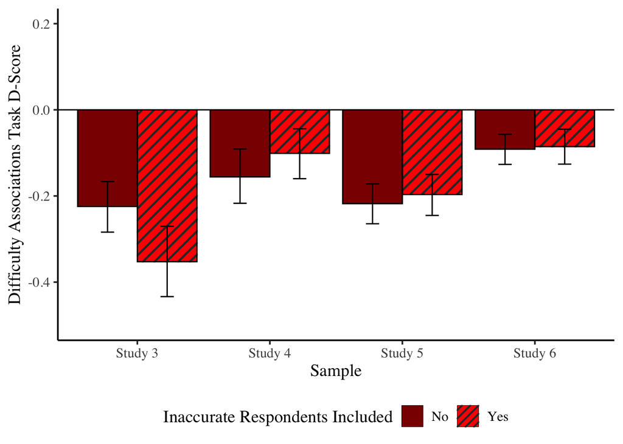

```r
import3<-ttestBF(study3_a$importavg, mu=3.5, posterior = FALSE, data=study3_a,
             iterations=2000)
```

```
## t is large; approximation invoked.
```

```r
import3_post<- ttestBF(study3_a$importavg, mu=3.5, posterior = TRUE, data=study3_a,
             iterations=2000)
import4<- ttestBF(study4_a$importavg, mu=3.5, posterior = FALSE, data=study4_a ,
             iterations=2000)
import4_post<- ttestBF(study4_a$importavg, mu=3.5, posterior = TRUE, data=study4_a ,
             iterations=2000)
import5<- ttestBF(study5_a$importavg, mu=3.5, posterior = FALSE, data=study5_a ,
             iterations=2000)
```

```
## t is large; approximation invoked.
```

```r
import5_post<- ttestBF(study5_a$importavg, mu=3.5, posterior = TRUE, data=study5_a ,
           iterations=2000)
import6<- ttestBF(study6_a$importavg, mu=3, posterior = FALSE, data=study6_a ,
             iterations=2000)
import6_post<- ttestBF(study6_a$importavg, mu=3, posterior = TRUE, data=study6_a ,
             iterations=2000)
summary(import3)
```

```
## Bayes factor analysis
## --------------
## [1] Alt., r=0.707 : 2.990066e+40 ±0%
##
## Against denominator:
##   Null, mu = 3.5
## ---
## Bayes factor type: BFoneSample, JZS
```

```r
summary(import3_post)
```

```
##
## Iterations = 1:2000
## Thinning interval = 1
## Number of chains = 1
## Sample size per chain = 2000
##
## 1. Empirical mean and standard deviation for each variable,
##    plus standard error of the mean:
##
##          Mean        SD  Naive SE Time-series SE
## mu     4.3102   0.05085  0.001137       0.001226
## sig2   0.8999   0.06985  0.001562       0.001562
## delta  4.5539   0.18335  0.004100       0.004330
## g     83.1268 675.33087 15.100857      15.100857
##
## 2. Quantiles for each variable:
##
##         2.5%    25%    50%     75%   97.5%
## mu    4.2074 4.2770  4.310  4.3462   4.410
## sig2  0.7703 0.8524  0.897  0.9451   1.050
## delta 4.1937 4.4302  4.548  4.6783   4.922
## g     2.9027 7.5379 15.184 38.2492 428.914
```

```r
summary(import4)
```

```
## Bayes factor analysis
## --------------
## [1] Alt., r=0.707 : 1.781003e+31 ±0%
##
## Against denominator:
##   Null, mu = 3.5
## ---
## Bayes factor type: BFoneSample, JZS
```

```r
summary(import4_post)
```

```
##
## Iterations = 1:2000
## Thinning interval = 1
## Number of chains = 1
## Sample size per chain = 2000
##
## 1. Empirical mean and standard deviation for each variable,
##    plus standard error of the mean:
##
##           Mean        SD  Naive SE Time-series SE
## mu      4.3456 6.020e-02  0.001346       0.001455
## sig2    0.9021 8.211e-02  0.001836       0.001836
## delta   4.5894 2.164e-01  0.004839       0.005299
## g     114.6307 1.711e+03 38.259771      38.259771
##
## 2. Quantiles for each variable:
##
##         2.5%    25%     50%     75%   97.5%
## mu    4.2283 4.3053  4.3450  4.3893   4.460
## sig2  0.7615 0.8431  0.8966  0.9541   1.076
## delta 4.1652 4.4413  4.5911  4.7344   4.996
## g     2.8719 7.9665 14.9209 36.1204 522.764
```

```r
summary(import5)
```

```
## Bayes factor analysis
## --------------
## [1] Alt., r=0.707 : 9.203378e+86 ±0%
##
## Against denominator:
##   Null, mu = 3.5
## ---
## Bayes factor type: BFoneSample, JZS
```

```r
summary(import5_post)
```

```
##
## Iterations = 1:2000
## Thinning interval = 1
## Number of chains = 1
## Sample size per chain = 2000
##
## 1. Empirical mean and standard deviation for each variable,
##    plus standard error of the mean:
##
##           Mean        SD  Naive SE Time-series SE
## mu      4.3347 3.560e-02 7.960e-04      7.377e-04
## sig2    0.7893 4.388e-02 9.812e-04      9.812e-04
## delta   4.8847 1.392e-01 3.113e-03      3.113e-03
## g     199.1381 2.969e+03 6.639e+01      9.409e+01
##
## 2. Quantiles for each variable:
##
##        2.5%    25%     50%    75%    97.5%
## mu    4.262 4.3109  4.3361  4.358   4.4011
## sig2  0.710 0.7581  0.7876  0.818   0.8793
## delta 4.611 4.7902  4.8847  4.984   5.1562
## g     3.210 8.9468 17.5531 44.918 539.8152
```

```r
summary(import6)
```

```
## Bayes factor analysis
## --------------
## [1] Alt., r=0.707 : 2.329771e+40 ±0%
##
## Against denominator:
##   Null, mu = 3
## ---
## Bayes factor type: BFoneSample, JZS
```

```r
summary(import6_post)
```

```
##
## Iterations = 1:2000
## Thinning interval = 1
## Number of chains = 1
## Sample size per chain = 2000
##
## 1. Empirical mean and standard deviation for each variable,
##    plus standard error of the mean:
##
##          Mean        SD  Naive SE Time-series SE
## mu      3.319 2.222e-02 4.968e-04      4.866e-04
## sig2    0.636 2.504e-02 5.598e-04      5.598e-04
## delta   4.164 8.674e-02 1.940e-03      2.013e-03
## g     266.475 8.056e+03 1.801e+02      1.801e+02
##
## 2. Quantiles for each variable:
##
##         2.5%    25%     50%     75%    97.5%
## mu    3.2761 3.3042  3.3201  3.3349   3.3614
## sig2  0.5892 0.6182  0.6358  0.6523   0.6874
## delta 3.9973 4.1062  4.1637  4.2244   4.3334
## g     2.5015 6.7193 13.1648 32.3500 372.3199
```

```r
set.seed(12345)

imposs3<- ttestBF(study3_b$impossavg, mu=3.5, posterior = FALSE, data=study3_b ,
             iterations=2000)
imposs3_post<- ttestBF(study3$impossavg, mu=3.5, posterior = TRUE, data=study3_b ,
             iterations=2000)
imposs4<- ttestBF(study4_b$impossavg, mu=3.5, posterior = FALSE, data=study4_b,
             iterations=2000)
imposs4_post<- ttestBF(study4_b$impossavg, mu=3.5, posterior = TRUE, data=study4_b ,
             iterations=2000)
imposs5<- ttestBF(study5_b$impossavg, mu=3.5, posterior = FALSE, data=study5_b ,
             iterations=2000)
```

```
## t is large; approximation invoked.
```

```r
imposs5_post<- ttestBF(study5_b$impossavg, mu=3.5, posterior = TRUE, data=study5_b ,
           iterations=2000)
imposs6<- ttestBF(study6_b$impossavg, mu=3, posterior = FALSE, data=study6_b ,
             iterations=2000)
```

```
## t is large; approximation invoked.
```

```r
imposs6_post<- ttestBF(study6_b$impossavg, mu=3, posterior = TRUE, data=study6_b ,
             iterations=2000)
summary(imposs3)
```

```
## Bayes factor analysis
## --------------
## [1] Alt., r=0.707 : 4.21602e+27 ±0%
##
## Against denominator:
##   Null, mu = 3.5
## ---
## Bayes factor type: BFoneSample, JZS
```

```r
summary(imposs3_post)
```

```
##
## Iterations = 1:2000
## Thinning interval = 1
## Number of chains = 1
## Sample size per chain = 2000
##
## 1. Empirical mean and standard deviation for each variable,
##    plus standard error of the mean:
##
##          Mean        SD  Naive SE Time-series SE
## mu      2.749 6.684e-02 1.495e-03      1.495e-03
## sig2    1.187 1.066e-01 2.385e-03      2.632e-03
## delta   2.531 1.310e-01 2.929e-03      3.089e-03
## g     145.712 4.885e+03 1.092e+02      1.092e+02
##
## 2. Quantiles for each variable:
##
##         2.5%   25%   50%    75%   97.5%
## mu    2.6184 2.703 2.748  2.795   2.878
## sig2  0.9980 1.112 1.181  1.253   1.412
## delta 2.2654 2.446 2.529  2.619   2.781
## g     0.8855 2.405 4.942 12.057 131.911
```

```r
summary(imposs4)
```

```
## Bayes factor analysis
## --------------
## [1] Alt., r=0.707 : 1.021693e+18 ±0%
##
## Against denominator:
##   Null, mu = 3.5
## ---
## Bayes factor type: BFoneSample, JZS
```

```r
summary(imposs4_post)
```

```
##
## Iterations = 1:2000
## Thinning interval = 1
## Number of chains = 1
## Sample size per chain = 2000
##
## 1. Empirical mean and standard deviation for each variable,
##    plus standard error of the mean:
##
##         Mean       SD Naive SE Time-series SE
## mu     2.762  0.07098 0.001587       0.001587
## sig2   1.290  0.11423 0.002554       0.002554
## delta  2.438  0.12401 0.002773       0.002773
## g     20.713 95.44015 2.134107       2.213551
##
## 2. Quantiles for each variable:
##
##         2.5%   25%   50%    75%   97.5%
## mu    2.6213 2.716 2.763  2.809   2.900
## sig2  1.0771 1.214 1.284  1.360   1.538
## delta 2.1886 2.359 2.438  2.516   2.684
## g     0.9016 2.400 4.810 11.252 128.341
```

```r
summary(imposs5)
```

```
## Bayes factor analysis
## --------------
## [1] Alt., r=0.707 : 1.75563e+73 ±0%
##
## Against denominator:
##   Null, mu = 3.5
## ---
## Bayes factor type: BFoneSample, JZS
```

```r
summary(imposs5_post)
```

```
##
## Iterations = 1:2000
## Thinning interval = 1
## Number of chains = 1
## Sample size per chain = 2000
##
## 1. Empirical mean and standard deviation for each variable,
##    plus standard error of the mean:
##
##          Mean        SD  Naive SE Time-series SE
## mu     2.6695   0.03882 0.0008681      0.0008681
## sig2   0.9699   0.05402 0.0012080      0.0012080
## delta  2.7137   0.08466 0.0018930      0.0018930
## g     30.6700 221.22496 4.9467405      4.9467405
##
## 2. Quantiles for each variable:
##
##         2.5%    25%    50%    75%   97.5%
## mu    2.5971 2.6431 2.6692  2.696   2.748
## sig2  0.8681 0.9328 0.9681  1.005   1.077
## delta 2.5512 2.6579 2.7152  2.769   2.880
## g     1.0596 2.9559 5.8087 14.070 153.682
```

```r
summary(imposs6)
```

```
## Bayes factor analysis
## --------------
## [1] Alt., r=0.707 : 1.246871e+105 ±0%
##
## Against denominator:
##   Null, mu = 3
## ---
## Bayes factor type: BFoneSample, JZS
```

```r
summary(imposs6_post)
```

```
##
## Iterations = 1:2000
## Thinning interval = 1
## Number of chains = 1
## Sample size per chain = 2000
##
## 1. Empirical mean and standard deviation for each variable,
##    plus standard error of the mean:
##
##          Mean        SD  Naive SE Time-series SE
## mu     2.4597 2.227e-02 4.979e-04      4.979e-04
## sig2   0.6347 2.458e-02 5.495e-04      5.679e-04
## delta  3.0892 6.644e-02 1.486e-03      1.486e-03
## g     97.1218 3.131e+03 7.001e+01      7.001e+01
##
## 2. Quantiles for each variable:
##
##        2.5%    25%    50%     75%   97.5%
## mu    2.416 2.4445 2.4602  2.4746   2.504
## sig2  0.589 0.6174 0.6335  0.6509   0.686
## delta 2.956 3.0453 3.0902  3.1344   3.213
## g     1.311 3.5008 6.9162 16.6916 185.200
```

```r
results<-tibble(
  sample=c("Study 3", "Study 4", "Study 5", "Study 6","Study 3", "Study 4", "Study 5", "Study 6"),
  mindset=c("Difficulty-As-Importance", "Difficulty-As-Importance", "Difficulty-As-Importance", "Difficulty-As-Importance",
            "Difficulty-As-Impossibility", "Difficulty-As-Impossibility", "Difficulty-As-Impossibility", "Difficulty-As-Impossibility"),
  mindsetmean=c(4.3086, 4.3477 , 4.3342, 3.3187,
                2.763, 2.762, 2.6695, 2.4597),
  lb=c(4.2069, 4.2284, 4.2656, 3.2754,
       2.6516, 2.6213, 2.5971, 2.416),
  ub=c(4.405, 4.473, 4.4015, 3.3615,
       2.875, 2.900, 2.748, 2.504),
  bf10=c(2.990066e+40, 1.781003e+31,  9.203378e+86, 2.329771e+40,
         4.21602e+27, 1.021693e+18, 1.75563e+73, 1.246871e+105))


results
```

```
## # A tibble: 8 × 6
##   sample  mindset                     mindsetmean    lb    ub     bf10
##   <chr>   <chr>                             <dbl> <dbl> <dbl>    <dbl>
## 1 Study 3 Difficulty-As-Importance           4.31  4.21  4.40 2.99e 40
## 2 Study 4 Difficulty-As-Importance           4.35  4.23  4.47 1.78e 31
## 3 Study 5 Difficulty-As-Importance           4.33  4.27  4.40 9.20e 86
## 4 Study 6 Difficulty-As-Importance           3.32  3.28  3.36 2.33e 40
## 5 Study 3 Difficulty-As-Impossibility        2.76  2.65  2.88 4.22e 27
## 6 Study 4 Difficulty-As-Impossibility        2.76  2.62  2.9  1.02e 18
## 7 Study 5 Difficulty-As-Impossibility        2.67  2.60  2.75 1.76e 73
## 8 Study 6 Difficulty-As-Impossibility        2.46  2.42  2.50 1.25e105
```